# 民主政治 民主制度的擴展：從西歐走向世界

師大公領系教授 黃信豪

2020/10

# Topics

**一、英國議會內閣制的演進**  
**二、美國革命：聯邦制度的嘗試**  
**三、歐陸集權王室的興衰**  
**四、工業革命的後果與普選權的流傳**

**指定閱讀：民主的全球旅程：從歐洲走向世界，Ch.2-6；民主及其批判，Ch.2、15-17。**

# 一、英國議會內閣制的演進

### （一）背景：王室、貴族的鬥爭

- 主要行動者：國王、貴族、騎士、平民（自由民：享權利特許狀的土地所有者）

### （二）經歷與發展：賢人(者)會議 $\Rightarrow$ 大會議 $\Rightarrow$ 模範議會 $\Rightarrow$ 兩院制

- 賢人(者)會議：七世紀後出現，國王召開，由宗教領袖、領主等貴族代表所組成。
- 1.大憲章(1215年-)：**議會**抬頭，制約國王權力。
- 2.大會議(1135-1154年)：國王反擊。
- 3.模範議會(1295年)：各級**貴族**、**教士**，各級行政單位的**騎士與市民代表**。
- 4.平民院（1322年）：為抗衡「貴族院」，英王組成「平民院」$\rightarrow$ 今日「兩院制」雛形。
- 其他重要的後續發展：
  - (1)從「樞密院」到「內閣」：從「被諮詢」，到賦予「行政任務」。
  - (2)14-15世紀連年戰爭：農民起義，1414年改革法案。
  - (3)1688年光榮革命：確認國會擁有立法最高性質。
  - (4)內閣組成與總辭：1721年多數黨組閣、1742年先例。
  - (5)1911年國會法：貴族院僅剩象徵權力。

### （三）為何王權無法再起？

- 1.習慣法傳統：制度堆積。
- 2.王室無法與「個人」結盟：新教的個人主義傳統。
- 3.戰事因素：國王缺乏專屬武力，難以擴權。

### （四）小結

- 18世紀中形成今日**議會內閣制**框架，但到20世紀初期前，控制政府的仍是**少數貴族**、**自由民**。
  - 主要來自**上層階級**的矛盾 $\rightarrow$ 確立「議會問責」制度。

# 二、美國革命：聯邦制度的嘗試

### （一）背景：荷蘭的聯合省經驗

- 1568-1648年尼得蘭革命，建立「聯合省制度」。
  - 讓各省保留主權，**各省議會**由城市、地方貴族、教會代表組成；**聯省議會**由各省議會選出的代表出席。
- 美國獨立：第一批殖民者，參考荷蘭經驗，建立聯邦制度。
  - 清教徒：反權威色彩；無明顯社會階層差異 $\rightarrow$ 簽訂五月花公約(1620年)。
    - 「人民同意」原則：同意創建一政府，政府將基於被管理者同意而成立，依法而治。

### （二）經歷與發展：

- 獨立後各州分權，只剩名義上國家。1787年費城制憲會議：
  - (1)對中央、各州分別賦予權力；(2)代表不同利益的兩院制國會架構；(3)總統作為國家元首，兩任慣例。
  - 憲法第22條修正案（小羅斯福條款）。
- 聯邦制變遷與總統權力的擴張：
  - 1.西進運動：基礎建設的需求。
  - 2.兩次世界大戰中美國的角色。
  - 3.國際影響力的上升。

### （三）小結：

- 現今總統權力已超越當初制憲者的預期；多數拉美國家仿效美國制度。

# 三、歐陸集權王室的興衰

### （一）背景：15、16世紀後「中央集權君主制」漸為歐陸主流，Why?

- 法國的案例：1180年腓力二世國王建立王權、中央集權官僚體系。
- 14世紀的瘟疫、黑死病 $\rightarrow$ 英、法截然不同的發展？
  - 法蘭西國家建立的過程：打仗、賣官（平民起義的遠因）。

### （二）經歷與發展：16-18世紀歐陸民族國家的潮流

- 1.外部因素：地理大發現、海外殖民的競爭；中古後期的各國戰爭 $\rightarrow$ 現代國家的政府結構。
- 2.內部因素：(1)十字軍東征後，貴族東遷；(2)工商業發展快，人民對秩序的渴望。
- 3.意識型態：布丹的「主權觀」。
- 1648年西發里亞條約：1.承認喀爾文教派的合法地位；2.各諸侯國可自訂官方宗教；3.各諸侯國擁有主權、外交權；4.正式承認瑞士等數個國家的獨立地位。
- 法國王權的「短暫」衰亡：1789年法國大革命。
  - 三級會議 $\rightarrow$ 國民議會；隨即拿破崙崛起。

### （三）小結

- 平民起義帶來深遠影響：**相關思想**流傳，侵蝕各國王權。
- 1848年的武裝革命浪潮：雖然失敗告終，但造成了各國君主與貴族體制動搖。

# 四、工業革命的後果與普選權的流傳

### 工業革命的擴散性後果

- 主要社會群體：
  - 1.中產階級：傾向支持「自由」、「權利」（法律保障），不見得要「民主」。
  - 2.勞動階級：追求「民主」。
  - 3.地主：既得利益者，反對「民主」。
  - 4.農民：各地不一（反動or保守？）。
- 西方國家的共同經驗：工業革命、都市化 $\rightarrow$ 農民、勞動階級、中產階級共同對抗既得利益。
- 大眾政黨的出現：組織、動員不同社會群體 $\rightarrow$ 「政治參與」普及。
- 發展：工業革命+1848年歐洲武裝革命後，各國雖恢復王權，但大多開始進行政治改革：e.g.普魯士、法國、英國。

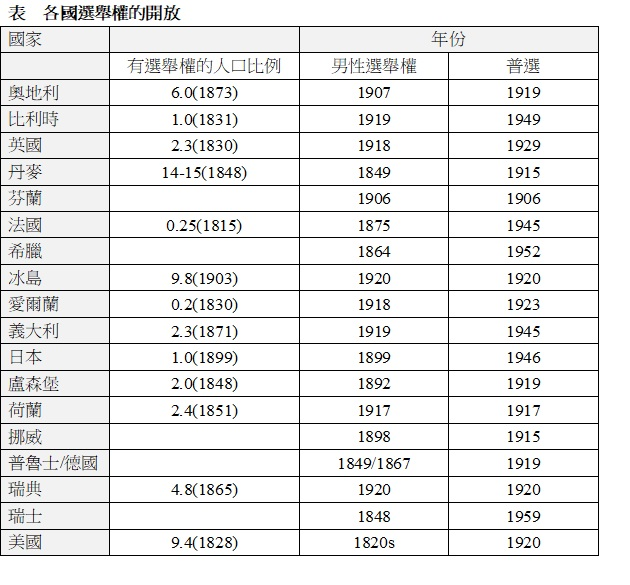

# 五、小結

- **西方的民主政治，醞釀了相當長的時間。**
  - 1.不同行動者的互動：各國的制度起源，都有其**社會結構與歷史因素**。
  - 2.傾向民主的思想扮演推手，但需要一定的**社會條件**支持。。
  - 3.共同的社會驅力：工業革命的**社會動員**效果。
- **民主的發展並非單向、各國王權仍有許多「限制」嘗試。**
  - 普魯士「三層投票制度」、英國與義大利「上議院地位」、法國「政體更替」等…
- **「民主」與「反民主」觀念的交纏：如Mill的『論自由』。**
  - 反對普選、反對選舉權平等。
  - 反對民主的觀點中，也有現代民主價值。
- **歐洲國家的民主旅程是漫長過程，「開放普選權」僅是一個里程碑。**
  - 1.在兩次世界大戰，「民族生存」優先於「民主制度」。
  - 2.一次大戰後，許多國家才開放男性普選權。
  - 3.中、東歐戰後經濟失序 $\rightarrow$ 法西斯主義、共產主義的崛起。
  - **直到20世紀後半，歐洲才有穩定的民主秩序，某些國家甚至到1990年。**